# stchlk_exome_annotation.Rmd

Kevin Stachelek

1/30/2018

load rb datasets. Keep in mind that only samples c(“24-T”, “28-C”, “28-T”, “29-T”, “29-C”, “31-T”, “31-C”, “41-C”, “46-T”, “46-C”, “48-T”, “48-C”) have ready rb variants detected

# 1. load packages

# 5. load unrefined m2 variants

# 13. load unrefined strelka variants

# 7. compile list of variants from all prior studies (Kooi, Zhang, McEvoy, Grobner w/o St. Jude Pecan

### load supplemental files

### clean supp info from prior studies

### prior author variants

# 8. compile list of sample characteristics from prior studies

# 9. tally samples per study

# 12. load list of variants from prior studies

# 5. load reported m2 variants

# 13. load reported strelka variants

# 14. ensemble variants

### vision center

# 15. tally vc ensemble variants

```
##
## Cell Line     Tumor
##        18        28
```

```
##
## Cell Line     Tumor
##        43        41
```

### reynolds ensemble variants

# 16. tally reynolds ensemble variants

```
##
## Cell Line
##      1363
```

# 17. load ensemble variants

vc

reynolds

full

# 18. compile all_author_variants: list of all genes from stachelek plus prior studies (Kooi, Zhang, McEvoy, Grobner)

### load prior author variants

```
## these are the prior studies
```

```
## $`gröbner et al.`
##  [1] "rb_e_013" "rb_e_023" "rb_e_011" "rb_e_015" "rb_e_016" "rb_e_018"
##  [7] "rb_e_020" "rb_e_021" "rb_e_022" "rb_e_026" "rb_e_027" "rb_e_036"
## [13] "rb_e_040" "rb_e_019"
##
## $`kooi et al.`
##  [1] "T38" "T67" "T22" "T66" "T17" "T61" "T68" "T29" "T62" "T3"  "T31"
## [12] "T65" "T23" "T57" "T63" "T71" "T27" "T10" "T58" "T64" "T7"  "T44"
## [23] "T18" "T54" "T13" "T48" "T11" "T34" "T69" "T2"  "T70" "T9"  "T21"
## [34] "T47" "T28" "T26" "T59" "T14" "T46" "T12" "T5"  "T52" "T49" "T6"
## [45] "T51" "T19" "T20" "T37" "T45" "T35" "T25" "T72" "T56" "T50" "T60"
## [56] "T32" "T4"  "T43" "T39" "T36" "T15" "T1"  "T16" "T24" "T8"  "T33"
## [67] "T40" "T41" "T55"
##
## $`mcevoy et al.`
## [1] "SJRB032_D" "SJRB031_D" "SJRB039_D" "SJRB051_D" "SJRB024_D" "SJRB011_D"
##
## $`zhang et al.`
## [1] "SJRB003DG" "SJRB001DG" "SJRB004DG" "SJRB002DG"
```

# 19. export somatic variants to supplemental information

### all author variants

### vc somatic variants

### reynolds somatic variants

# export reported variants as bed

# 6. find variants that are shared between mutect2 tumor and matched cell line

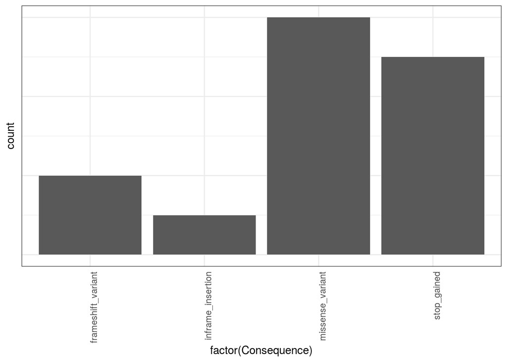

# 20. find prior author gene intersection with mutect2 vc somatic variants

# 21. find prior author gene intersection with mutect2 reynolds somatic variants

# 22. write prior author gene intersection with all variants

### load all author variants

### vc tumors and cell lines

### load recurrent vc tumors and cell lines

### reynolds cell lines

### load reynolds cell lines

# 23. load reported strelka variants

# 24. load reported m2 variants

# 25. waterfall plots

## load all author variants

## waterfall plot all tumor and/or cell line variants

# load data—————————–

# waterfall plot all author cl t

```
## Checking if input is properly formatted...
```

```
## Detected "Custom" file_type flag, looking for correct column names...
```

```
## Calculating frequency of mutations...
```

```
## setting mutation hierarchy...
```

[figure not shown]

# waterfall plot all author t

```
## Checking if input is properly formatted...
```

```
## Detected "Custom" file_type flag, looking for correct column names...
```

```
## Calculating frequency of mutations...
```

```
## setting mutation hierarchy...
```

[figure not shown]

# waterfall plot recurrent cl t

```
## Checking if input is properly formatted...
```

```
## Detected "Custom" file_type flag, looking for correct column names...
```

```
## Calculating frequency of mutations...
```

```
## setting mutation hierarchy...
```

[figure not shown]

# waterfall plot recurrent t

```
## Checking if input is properly formatted...
```

```
## Detected "Custom" file_type flag, looking for correct column names...
```

```
## Calculating frequency of mutations...
```

```
## setting mutation hierarchy...
```

[figure not shown]

# 26. Webgestalt analysis

### webgestalt plot all tumor and/or cell line variants

```
## Loading the functional categories...
## Loading the ID list...
## Loading the reference list...
## Summarizing the input ID list by GO Slim data...
```

```
## Performing the enrichment analysis...
## Begin affinity propagation...
## End affinity propagation...
## Begin weighted set cover...
## Remain is 0, ending weighted set cover
## Generate the final report...
## Results can be found in the /home/skevin/rb_pipeline/doc/RB_exome_manuscript/stachelek_supplemental/webgestalt/all_cl_t_w_reynolds_results/Project_1569272918!
```

### webgestalt plot all tumor and/or cell line variants

```
## Loading the functional categories...
## Loading the ID list...
## Loading the reference list...
## Summarizing the input ID list by GO Slim data...
```

```
## Performing the enrichment analysis...
## Begin affinity propagation...
## End affinity propagation...
## Begin weighted set cover...
## Remain is 0, ending weighted set cover
## Generate the final report...
## Results can be found in the /home/skevin/rb_pipeline/doc/RB_exome_manuscript/stachelek_supplemental/webgestalt/all_cl_t_results/Project_1569272924!
```

### webgestalt plot all tumor variants

```
## Loading the functional categories...
## Loading the ID list...
## Loading the reference list...
## Summarizing the input ID list by GO Slim data...
```

```
## Performing the enrichment analysis...
## Begin affinity propagation...
## End affinity propagation...
## Begin weighted set cover...
## Remain is 0, ending weighted set cover
## Generate the final report...
## Results can be found in the /home/skevin/rb_pipeline/doc/RB_exome_manuscript/stachelek_supplemental/webgestalt/all_t_results/Project_1569272930!
```

```
## Loading the functional categories...
## Loading the ID list...
## Loading the reference list...
## Summarizing the input ID list by GO Slim data...
```

```
## Performing the enrichment analysis...
## Begin affinity propagation...
## End affinity propagation...
## Begin weighted set cover...
## Remain is 0, ending weighted set cover
## Generate the final report...
## Results can be found in the /home/skevin/rb_pipeline/doc/RB_exome_manuscript/stachelek_supplemental/webgestalt/stachelek_cl_t_results/Project_1569272936!
```

```
## Loading the functional categories...
## Loading the ID list...
## Loading the reference list...
## Summarizing the input ID list by GO Slim data...
```

```
## Performing the enrichment analysis...
## Begin affinity propagation...
## End affinity propagation...
## Begin weighted set cover...
## Remain is 0, ending weighted set cover
## Generate the final report...
## Results can be found in the /home/skevin/rb_pipeline/doc/RB_exome_manuscript/stachelek_supplemental/webgestalt/stachelek_t_results/Project_1569272941!
```

### webgestalt recurrent tumor and/or cell line variants

```
## Loading the functional categories...
## Loading the ID list...
## Loading the reference list...
## Summarizing the input ID list by GO Slim data...
```

```
## Performing the enrichment analysis...
## Begin affinity propagation...
## End affinity propagation...
## Begin weighted set cover...
## Remain is 0, ending weighted set cover
## Generate the final report...
## Results can be found in the /home/skevin/rb_pipeline/doc/RB_exome_manuscript/stachelek_supplemental/webgestalt/recurrent_cl_t_results/Project_1569272947!
```

### webgestalt recurrent tumor variants

```
## Loading the functional categories...
## Loading the ID list...
## Loading the reference list...
## Summarizing the input ID list by GO Slim data...
```

```
## Performing the enrichment analysis...
## Begin affinity propagation...
## End affinity propagation...
## Begin weighted set cover...
## Remain is 0, ending weighted set cover
## Generate the final report...
## Results can be found in the /home/skevin/rb_pipeline/doc/RB_exome_manuscript/stachelek_supplemental/webgestalt/recurrent_t_results/Project_1569272956!
```

# 27. check Kooi MYCNA samples

```
## [1] "T7"  "T11" "T14" "T20" "T24" "T72"
```

# 28. check for recurrence of kooi SCNA genes

```
## # A tibble: 1 x 72
##   sample SYMBOL HGVSc HGVSp paramRangeID Allele Consequence IMPACT Gene
##   <chr>  <chr>  <chr> <chr> <chr>        <chr>  <chr>       <chr>  <chr>
## 1 223-CL CRB1   ENST… ENSP… chr1:197404… T      missense_v… MODER… ENSG…
## # … with 63 more variables: Feature_type <chr>, Feature <chr>,
## #   BIOTYPE <chr>, EXON <chr>, INTRON <lgl>, cDNA_position <chr>,
## #   CDS_position <chr>, Protein_position <chr>, Amino_acids <chr>,
## #   Codons <chr>, Existing_variation <lgl>, DISTANCE <lgl>, STRAND <dbl>,
## #   FLAGS <chr>, SYMBOL_SOURCE <chr>, HGNC_ID <dbl>, HGVS_OFFSET <dbl>,
## #   seqnames <chr>, start <dbl>, end <dbl>, width <dbl>, strand <chr>,
## #   REF <chr>, ALT <chr>, QUAL <lgl>, FILTER <chr>, GT.NORMAL <lgl>,
## #   GT.TUMOR <lgl>, AF.NORMAL <lgl>, AF.TUMOR <lgl>, AD.NORMAL.1 <lgl>,
## #   AD.TUMOR.1 <lgl>, AD.NORMAL.2 <lgl>, AD.TUMOR.2 <lgl>,
## #   gnomad.AF <dbl>, proteine <chr>, aaref <chr>, aaalt <chr>,
## #   rfPred_score <chr>, SIFT_score <chr>, MutationTaster_score <chr>,
## #   Polyphen2_score <chr>, PhyloP_score <chr>, LRT_score <chr>,
## #   aapos <chr>, Uniprot_id <chr>, genename <chr>, position_hg18 <chr>,
## #   Polyphen2_HDIV_score <chr>, Polyphen2_HDIV_pred <chr>,
## #   Polyphen2_HVAR_score <chr>, Polyphen2_HVAR_pred <chr>,
## #   MutationTaster_pred <chr>, phyloP <chr>, LRT_Omega <chr>,
## #   LRT_pred <chr>, recurrence <chr>, counts <dbl>, path_meta_score <dbl>,
## #   GT <chr>, AF <dbl>, AD.1 <dbl>, AD.2 <dbl>
```

# 29. Inspect variants ————————————–

look for variants in the same gene that are present more than once, using either varaint caller

# 30. inspect BCOR variants

In Strelka: 1. the BCOR variant at chrX 39932333 39932333 in 33-T is also present at final report in 33-CL. Both are present! 2. There is no evidence for the varaint at chrX 39921622 39921622 in either 28-CL or 28-T at any stage of filtering!

# 31. double check variant filtration?

look for variants that might have been mistakenly filtered based on the comparison between genes in the final filtered set and variants in those same genes in the unfiltered set

# 32. compare final variants to COSMIC Cancer Gene Census (CGC)

```
##  [1] "BCOR"     "BRCA2"    "BUB1B"    "CREBBP"   "EIF3E"    "IDH1"
##  [7] "KAT6A"    "LCP1"     "MET"      "NCOR2"    "NSD1"     "PDCD1LG2"
## [13] "PTPRK"    "PTPRT"    "SIRPA"    "MUC4"     "ATM"      "BCL11A"
## [19] "FAT4"     "GRIN2A"   "GRM3"     "ROS1"     "SALL4"    "TGFBR2"
## [25] "PDE4DIP"  "GNAS"     "MUC16"    "PRDM2"    "SMO"      "BARD1"
## [31] "BCL2"     "BCL2L12"  "CAMTA1"   "CBLC"     "CDC73"    "CHEK2"
## [37] "CNTRL"    "CPEB3"    "CSMD3"    "CUX1"     "DDX5"     "ERCC2"
## [43] "ERCC5"    "FANCC"    "FANCF"    "FANCG"    "FCRL4"    "GATA3"
## [49] "HSP90AA1" "ITK"      "KAT7"     "KDM5C"    "KMT2A"    "KMT2C"
## [55] "MAFB"     "MECOM"    "MKL1"     "MSH6"     "MYH11"    "NCKIPSD"
## [61] "NUMA1"    "NUP214"   "PCM1"     "PML"      "PRDM16"   "RNF213"
## [67] "RNF43"    "SETD1B"   "SFPQ"     "STIL"     "TFEB"     "TLX1"
## [73] "TMPRSS2"  "WT1"      "ZMYM3"    "ZNRF3"
```

# 33. compare final variants to Lawrence et. al saturation analysis genes

```
## # A tibble: 24 x 26
##    sample author gene  Consequence    VAF VAF.m2 VAF.strelka HGVSp chr
##    <chr>  <chr>  <chr> <chr>        <dbl>  <dbl>       <dbl> <chr> <chr>
##  1 T23    kooi … BCOR  <NA>         0.188 NA          NA     <NA>  chrX
##  2 T57    kooi … BCOR  <NA>         0.375 NA          NA     <NA>  chrX
##  3 T61    kooi … BCOR  <NA>         0.5   NA          NA     <NA>  chrX
##  4 T63    kooi … BCOR  <NA>         0.465 NA          NA     <NA>  chrX
##  5 T66    kooi … BCOR  <NA>         0.917 NA          NA     <NA>  chrX
##  6 rb_e_… gröbn… BCOR  <NA>        NA     NA          NA     <NA>  chrX
##  7 T47    kooi … CREB… <NA>         0.273 NA          NA     <NA>  chr16
##  8 T62    kooi … CREB… <NA>         0.173 NA          NA     <NA>  chr16
##  9 33-CL  stach… BCOR  stop_gained NA      0.21        0.206 ENSP… chrX
## 10 28-T   stach… BCOR  frameshift… NA      0.423       0.413 ENSP… chrX
## # … with 14 more rows, and 17 more variables: start <dbl>, end <dbl>,
## #   hg18_pos <dbl>, ref <chr>, alt <chr>, AD.NORMAL.1.m2 <dbl>,
## #   AD.NORMAL.2.m2 <dbl>, AD.TUMOR.1.m2 <dbl>, AD.TUMOR.2.m2 <dbl>,
## #   AD.NORMAL.1.strelka <dbl>, AD.NORMAL.2.strelka <dbl>,
## #   AD.TUMOR.1.strelka <dbl>, AD.TUMOR.2.strelka <dbl>, sample_type <chr>,
## #   series <chr>, tumor_type <chr>, qval <dbl>
```

# 34. Compare recurrent variants with list of all unfiltered variants

### load unrefined m2 variants

### compare

# 34. check for overlap between stchlk SCNAs and Kooi SCNA peak regions

# 35. find overlapping segments in SCNA

# 36. play with somatic signatures

# 37. plot VAF distribution